# lab10 Vanilla CNN and Fine-Tune VGG16 - for Dogs and Cats Classification

## Introduction

In this lab, using fine-tune VGG16 to classify pictures (dogs and cats).

```python
from tensorflow import keras
from tensorflow.keras import layers
from PIL import Image
import tensorflow as tf

import numpy as np
import pandas as pd
import matplotlib.pyplot as plt
import seaborn as sns
from tensorflow.keras.utils import image_dataset_from_directory
from sklearn.metrics import confusion_matrix, precision_score
from sklearn.metrics import classification_report
from sklearn.metrics import precision_recall_curve
```

### 1. Obtain the data: Get the Dogs vs Cats dataset

```python
import os, shutil, pathlib

original_dir = pathlib.Path("../data/kaggle_dogs_vs_cats/train")
new_base_dir = pathlib.Path("../data/kaggle_dogs_vs_cats_small")

def make_subset(subset_name, start_index, end_index):
    for category in ("cat", "dog"):
        dir = new_base_dir / subset_name / category
        os.makedirs(dir)
        fnames = [f"{category}.{i}.jpg" for i in range(start_index, end_index)]
        for fname in fnames:
            shutil.copyfile(src=original_dir / fname,
                            dst=dir / fname)

make_subset("train", start_index=0, end_index=1000)
make_subset("validation", start_index=1000, end_index=1500)
make_subset("test", start_index=1500, end_index=2500)
```

## Data Exploration

### 2. EDA: Explore the data with relevant graphs, statistics and insights

```python
data_folder = pathlib.Path('../data/kaggle_dogs_vs_cats_small')

train_dataset = image_dataset_from_directory(
    data_folder / "train",
    image_size=(180, 180),
    batch_size=32)
validation_dataset = image_dataset_from_directory(
    data_folder / "validation",
    image_size=(180, 180),
    batch_size=32)
test_dataset = image_dataset_from_directory(
    data_folder / "test",
    shuffle=False,
    image_size=(180, 180),
    batch_size=32)
```

```
Found 2000 files belonging to 2 classes.
Found 1000 files belonging to 2 classes.
Found 2000 files belonging to 2 classes.
```

```python
for image, label in train_dataset:
    print(image.shape)
    print(label.shape)
    break
```

```
(32, 180, 180, 3)
(32,)
```

There are 32 images each with a resolution of 180X180 pixels and RGB channels. And the label data is in the form (32,), where the labels for each of the 32 images are provided as a one-dimensional array.

- sample images of dogs and cats

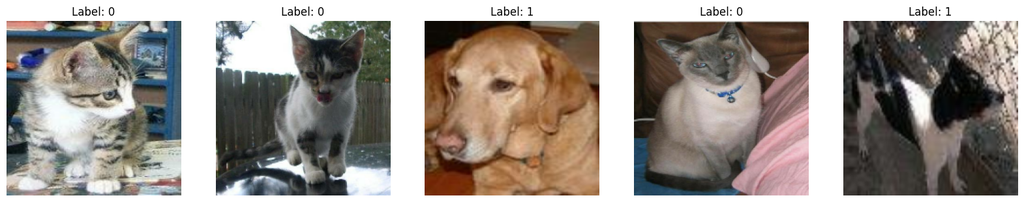

```python
for images, labels in train_dataset.take(1):
    plt.figure(figsize=(20, 10))
    for i in range(5):
        plt.subplot(1, 5, i + 1)
        plt.imshow(images[i].numpy().astype("uint8"))
        plt.title(f"Label: {labels[i]}")
        plt.axis("off")
    plt.show()
```

I extracted 5 sample images, and they seem to represent cats and dogs. Some of the images show significant differences in brightness and contrast. The last image in particular appears to be of poor quality or distorted.

- Distribution of class variable

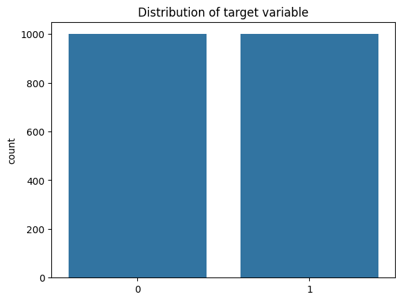

```python
labels = np.concatenate([y.numpy() for _, y in train_dataset], axis=0)
sns.countplot(x=labels)
plt.title("Distribution of target variable")
plt.show()
```

The countplot shows the distribution of target variable. It has two classes ('0' and '1'). It has balanced classes and there are 1000 data for each class.

- Distribution of pixel value

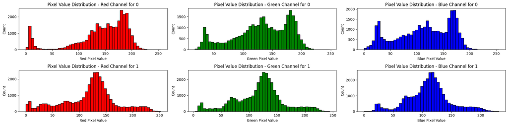

```python
for data_batch, labels_batch in train_dataset.take(1):
    fig, axes = plt.subplots(2, 3, figsize=(20, 5))

    class_0_indices = tf.where(labels_batch == 0)
    class_0_indices = class_0_indices.numpy().flatten()
    for i, color in enumerate(['Red', 'Green', 'Blue']):
        if len(class_0_indices) > 0:
            first_class_0_image = data_batch[class_0_indices[0]].numpy()
            pixels = first_class_0_image[:, :, i].flatten()
            axes[0, i].hist(pixels, bins=50, color=color.lower(), edgecolor='black')
            axes[0, i].set_title(f'Pixel Value Distribution - {color} Channel for 0')
            axes[0, i].set_xlabel(f'{color} Pixel Value')
            axes[0, i].set_ylabel('Count')
        else:
            axes[0, i].set_title(f'No images for class 0')

    class_1_indices = tf.where(labels_batch == 1)
    class_1_indices = class_1_indices.numpy().flatten()
    for i, color in enumerate(['Red', 'Green', 'Blue']):
        if len(class_1_indices) > 0:
            first_class_1_image = data_batch[class_1_indices[0]].numpy()
            pixels = first_class_1_image[:, :, i].flatten()
            axes[1, i].hist(pixels, bins=50, color=color.lower(), edgecolor='black')
            axes[1, i].set_title(f'Pixel Value Distribution - {color} Channel for 1')
            axes[1, i].set_xlabel(f'{color} Pixel Value')
            axes[1, i].set_ylabel('Count')
        else:
            axes[1, i].set_title(f'No images for class 1')

    plt.tight_layout()
    plt.show()
```

The histograms show the distribution of pixel values across the Red, Green, and Blue channels for two classes ('0' and '1').

## Modeling

### 3. Train two networks

#### 1) Define a Neural Network of your choice

```python
inputs = keras.Input(shape=(180, 180, 3))
x = layers.Rescaling(1./255)(inputs)
x = layers.Conv2D(filters=32, kernel_size=3, activation="relu")(x)
x = layers.MaxPooling2D(pool_size=2)(x)
x = layers.Conv2D(filters=64, kernel_size=3, activation="relu")(x)
x = layers.MaxPooling2D(pool_size=2)(x)
x = layers.Conv2D(filters=128, kernel_size=3, activation="relu")(x)
x = layers.MaxPooling2D(pool_size=2)(x)
x = layers.Conv2D(filters=256, kernel_size=3, activation="relu")(x)
x = layers.MaxPooling2D(pool_size=2)(x)
x = layers.Conv2D(filters=256, kernel_size=3, activation="relu")(x)
x = layers.Flatten()(x)
outputs = layers.Dense(1, activation="sigmoid")(x)
model = keras.Model(inputs=inputs, outputs=outputs)
```

```python
model.compile(loss="binary_crossentropy",
              optimizer="rmsprop",
              metrics=["accuracy"])
```

```python
callbacks = [
    keras.callbacks.ModelCheckpoint(
        filepath="./models/convnet_from_scratch.keras",
        save_best_only=True,
        monitor="val_loss")
]
history = model.fit(
    train_dataset,
    epochs=30,
    validation_data=validation_dataset,
    callbacks=callbacks)
```

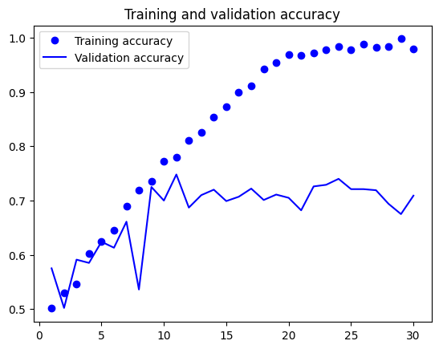

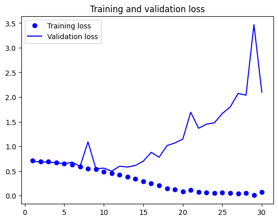

```python
accuracy = history.history["accuracy"]
val_accuracy = history.history["val_accuracy"]
loss = history.history["loss"]
val_loss = history.history["val_loss"]
epochs = range(1, len(accuracy) + 1)
plt.plot(epochs, accuracy, "bo", label="Training accuracy")
plt.plot(epochs, val_accuracy, "b", label="Validation accuracy")
plt.title("Training and validation accuracy")
plt.legend()
plt.figure()
plt.plot(epochs, loss, "bo", label="Training loss")
plt.plot(epochs, val_loss, "b", label="Validation loss")
plt.title("Training and validation loss")
plt.legend()
plt.show()
```

Training and Validation Accuracy:

- the training accuracy improves consistently as training progresses, which is a good sign that the model is learning from the data.
- However, the validation accuracy remains relatively flat and even decreases slightly over time. This indicates that the model is overfitting to the training data.

Training and Validation Loss:

- The training loss decreases over time, which indicates learning. It's not perfectly smooth, suggesting some volatility in the training process, but the overall trend is downward.
- The validation loss, however, increases sharply towards the end of the training. It indicates overfitting, where the model learns patterns specific to the training data, which do not generalize to the validation data.

#### 2) Fine-Tune VGG16(pre-trained on imagenet). Make sure to use validation to test for over-fitting. Plot the appropriate graph

download

```python
conv_base = keras.applications.vgg16.VGG16(
    weights="imagenet",
    include_top=False,
    input_shape=(180, 180, 3))
```

Define the model

```python
inputs = keras.Input(shape=(180, 180, 3))
x = keras.applications.vgg16.preprocess_input(inputs)
x = conv_base(x)
x = layers.Flatten()(x)
x = layers.Dense(256)(x)
x = layers.Dropout(0.5)(x)
outputs = layers.Dense(1, activation="sigmoid")(x)
model2 = keras.Model(inputs, outputs)
```

Freezing all layers until the fourth from the last

```python
conv_base.trainable = True
for layer in conv_base.layers[:-4]:
    layer.trainable = False
```

Fine-tuning the model

```python
model2.compile(loss="binary_crossentropy",
              optimizer=keras.optimizers.RMSprop(learning_rate=1e-5),
              metrics=["accuracy"])

callbacks2 = [
    keras.callbacks.ModelCheckpoint(
        filepath="./models/fine_tuning.keras",
        save_best_only=True,
        monitor="val_loss")
]
history2 = model2.fit(
    train_dataset,
    epochs=30,
    validation_data=validation_dataset,
    callbacks=callbacks2)
```

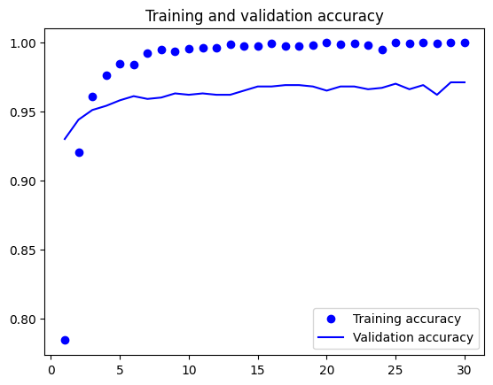

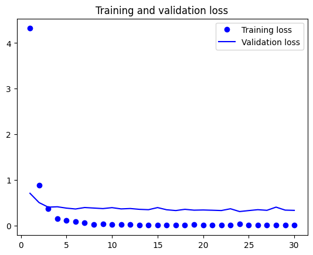

```python
acc = history2.history["accuracy"]
val_acc = history2.history["val_accuracy"]
loss = history2.history["loss"]
val_loss = history2.history["val_loss"]
epochs = range(1, len(acc) + 1)
plt.plot(epochs, acc, "bo", label="Training accuracy")
plt.plot(epochs, val_acc, "b", label="Validation accuracy")
plt.title("Training and validation accuracy")
plt.legend()
plt.figure()
plt.plot(epochs, loss, "bo", label="Training loss")
plt.plot(epochs, val_loss, "b", label="Validation loss")
plt.title("Training and validation loss")
plt.legend()
plt.show()
```

Training and Validation Accuracy:

Training and Validation Loss:

- The training loss drops sharply after the first few epochs and then continues to decrease gradually, settling into a stable pattern.
- The validation loss mirrors the training loss, which is a good sign. It stays consistent with the training loss, with no significant spikes or divergences that would suggest overfitting.

## Evaluation

### 4. Explore the relative performance of the models

#### 1) accuracy

CNN

the accuracy of the CNN model is 71.1%, indicating that the model correctly predicts approximately 71% of the test dataset.

```python
best_model = keras.models.load_model("./models/convnet_from_scratch.keras")
test_loss, test_acc = best_model.evaluate(test_dataset)
print(f"Test accuracy: {test_acc:.3f}")
```

```
Test accuracy: 0.711
```

Fine-Tune VGG16

```python
best_model2 = keras.models.load_model("./models/fine_tuning.keras")
test_loss, test_acc = best_model2.evaluate(test_dataset)
print(f"Test accuracy: {test_acc:.3f}")
```

```
Test accuracy: 0.967
```

#### 2) confusion matrix

CNN

```python
y = []
for image, label in test_dataset:
    y.extend(label.numpy().astype(int))
y = np.array(y)
y_pred_test = best_model.predict(test_dataset)
y_pred_class = (y_pred_test > 0.5).astype(int)
```

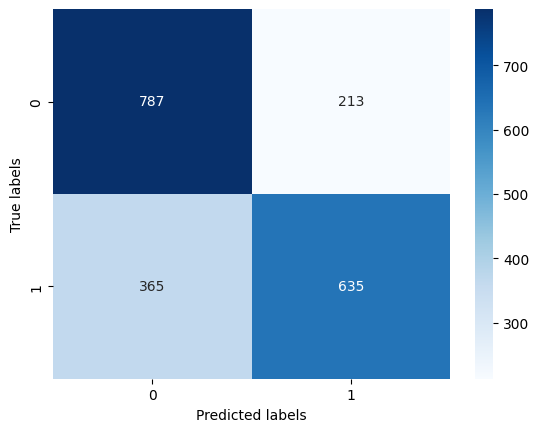

```python
cm = confusion_matrix(y, y_pred_class)
sns.heatmap(cm, annot=True, fmt="d", cmap="Blues")
plt.xlabel('Predicted labels')
plt.ylabel('True labels')
plt.show()
```

Fine-Tune VGG16

```python
y_pred2_test = best_model2.predict(test_dataset)
y_pred2_class = (y_pred2_test > 0.5).astype(int)
```

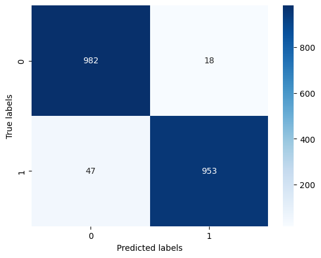

```python
cm = confusion_matrix(y, y_pred2_class)
sns.heatmap(cm, annot=True, fmt="d", cmap="Blues")
plt.xlabel('Predicted labels')
plt.ylabel('True labels')
plt.show()
```

- The overall number of correct predictions is high(982, 953), suggesting that the model has a good predictive capability.
- The False positive rate is very low, even lower than false negative.

#### 3) precision, recall, F1-score

CNN

```python
print(classification_report(y, y_pred_class))
```

```
              precision    recall  f1-score   support

           0       0.68      0.79      0.73      1000
           1       0.75      0.64      0.69      1000

    accuracy                           0.71      2000
   macro avg       0.72      0.71      0.71      2000
weighted avg       0.72      0.71      0.71      2000
```

Class 0:

- precision: out of all instances classified as class 0, 68% were actually class 0.
- recall: out of all actual instances of class 0, the model correctly identified 79% of them.
- f1-score: f1-score for class 0 is 73%, which is the harmonic mean of precision and recall.

Class 1:

- Precision: Out of all instances classified as class 1, 75% were actually class 1.
- Recall: The model correctly identified 64% of all actual instances of class 1.
- F1-Score: The F1-score for class 1 is 0.69.

Fine-Tune VGG16

```python
print(classification_report(y, y_pred2_class))
```

```
              precision    recall  f1-score   support

           0       0.95      0.98      0.97      1000
           1       0.98      0.95      0.97      1000

    accuracy                           0.97      2000
   macro avg       0.97      0.97      0.97      2000
weighted avg       0.97      0.97      0.97      2000
```

Class 0:

- Precision: High precision of 0.95 means that 95% of the predictions for class 0 were correct.
- Recall: A recall of 0.98 indicates that the model identified 98% of all actual class 0 instances correctly.
- F1-Score: The F1-score, which balances precision and recall, is 0.97, indicating an excellent harmonic mean for class 0.

Class 1:

- Precision: Even higher precision for class 1 at 0.98 suggests that 98% of the predictions for class 1 were correct.
- Recall: A slightly lower recall for class 1 at 0.95 still indicates a strong ability of the model to identify class 1 instances.
- F1-Score: The F1-score for class 1 matches that of class 0 at 0.97.

#### 4) precision-recall curve

CNN

```python
precisions, recalls, thresholds = precision_recall_curve(y, y_pred)
precision = precision_score(y, y_pred_test>=0.5)
```

```python
idx = np.where(precisions > precision)[0][0]
threshold = thresholds[idx-1]
```

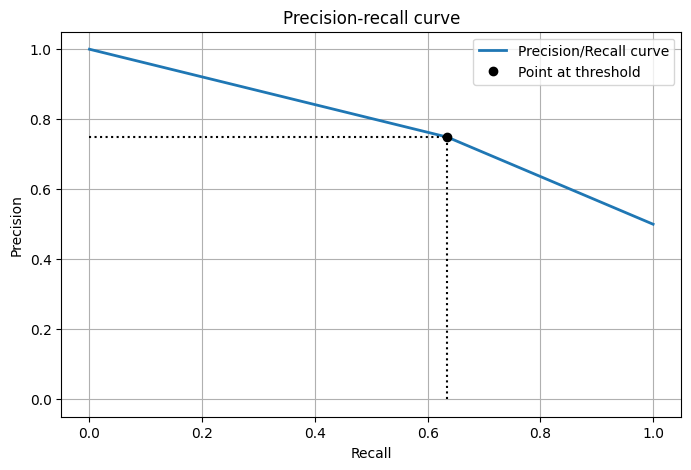

```python
idx = (thresholds >= threshold).argmax()
plt.figure(figsize=(8, 5))
plt.plot(recalls, precisions, linewidth=2, label="Precision/Recall curve")
plt.plot([recalls[idx], recalls[idx]], [0., precisions[idx]], "k:")
plt.plot([0.0, recalls[idx]], [precisions[idx], precisions[idx]], "k:")
plt.plot([recalls[idx]], [precisions[idx]], "ko",
         label="Point at threshold")
plt.xlabel("Recall")
plt.ylabel("Precision")
plt.title("Precision-recall curve")
plt.grid(True)
plt.legend()
plt.show()
```

- The selected threshold (where the black dot is) seems to prioritize precision slightly over recall. The model is more conservative about labeling a positive class, opting for being correct when it does so.
- The curve starts high and slopes downward. At the beginning (towards the left of the plot), when recall is low, the classifier is very precise. As we lower the threshold to classify more items as positive, recall increases, but precision drops because the classifier starts to include more false positives.

Fine-Tune VGG16

```python
precisions, recalls, thresholds = precision_recall_curve(y, y_pred2)
precision = precision_score(y, y_pred2_test>=0.5)
```

```python
idx = np.where(precisions > precision)[0][0]
threshold = thresholds[idx-1]
```

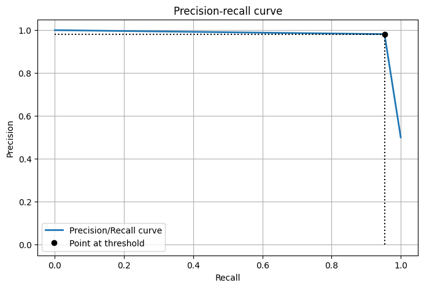

```python
idx = (thresholds >= threshold).argmax()
plt.figure(figsize=(8, 5))
plt.plot(recalls, precisions, linewidth=2, label="Precision/Recall curve")
plt.plot([recalls[idx], recalls[idx]], [0., precisions[idx]], "k:")
plt.plot([0.0, recalls[idx]], [precisions[idx], precisions[idx]], "k:")
plt.plot([recalls[idx]], [precisions[idx]], "ko",
         label="Point at threshold")
plt.xlabel("Recall")
plt.ylabel("Precision")
plt.title("Precision-recall curve")
plt.grid(True)
plt.legend()
plt.show()
```

#### 5) Explore specific examples in which the model failed to predict correctly

CNN

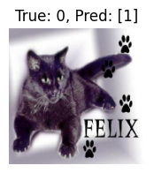

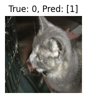

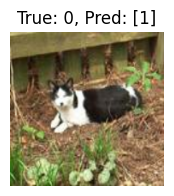

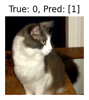

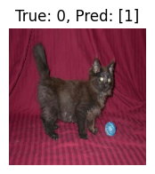

```python
misclassified_indices = np.where(y != y_pred_class.flatten())[0]

misclassified_samples = []

for i, (images, labels) in enumerate(test_dataset.unbatch()):
    if i in misclassified_indices:
        misclassified_samples.append((images, labels, y_pred_class[i]))

for (image, true_label, pred_label) in misclassified_samples[:5]:
    plt.figure(figsize=(2, 2))
    plt.imshow(image.numpy().astype('uint8'))
    plt.title(f'True: {true_label.numpy()}, Pred: {pred_label}')
    plt.axis('off')
    plt.show()
```

- The image may have features that are common in both classes, which could confuse the model.
- The image could be atypical of the class it represents.

Fine-Tune VGG16

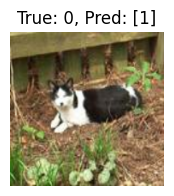

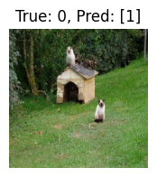

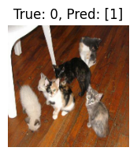

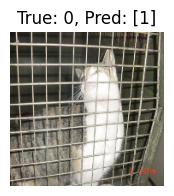

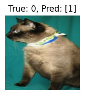

```python
misclassified_indices = np.where(y != y_pred2_class.flatten())[0]

misclassified_samples = []

for i, (images, labels) in enumerate(test_dataset.unbatch()):
    if i in misclassified_indices:
        misclassified_samples.append((images, labels, y_pred2_class[i]))

for (image, true_label, pred_label) in misclassified_samples[:5]:
    plt.figure(figsize=(2, 2))
    plt.imshow(image.numpy().astype('uint8'))
    plt.title(f'True: {true_label.numpy()}, Pred: {pred_label}')
    plt.axis('off')
    plt.show()
```

- Look for features in the background or setting that could be misleading the model.
- These are pictures where it seems difficult to recognize the shape of the cat.

## Conclusions

### 5. Add your conclusions

1. performance:
- the cnn model has an accuracy of 71% and the fine-tune vgg16 model has an accuracy of 96.7%, suggesting that the vgg16 model is significantly outperforming the CNN.
- The confusion matrix and precision-recall curve for vgg16 implies better at classifying and maintaining high accuracy.
2. model complexity:
- cnn model have fewer parameters and thus be quicker to train, but it may not capture as complex features as vgg16 unless it's specifically well-designed for the task.
- the vgg16 model is a deep network with multiple layers and is pre-trained on a large dataset. This can give it an advantage in feature extraction over a simpler cnn model.
3. overfitting:
- the cnn model overfit, it might not have the capacity to learn as detailed features as the vgg16.

In conclusion, the fine-tune vgg16 appears to be the superior model for accuracy and general performance based on the metrics provided.